# Final Report for Intro to Data Science

Victoria Cinquepalmi and Maggie Julian

video- https://web.microsoftstream.com/video/654e7ac4-22ae-4e57-a4fa-74fd3fbfe30f

slides- https://docs.google.com/presentation/d/1S-nmrpwXVyLgNh-qzCdaE22Q1fuqSNrvpMtZkDpLDUY/edit#slide=id.gc6f9e470d_0_0

github - https://github.com/magjulian10/final_project_ds

# 1 Introduction

The data set we chose was the billboard top 100 from 2015. We collected this data from Professor Sanchez-Arias Github.

| The Variables | What they do |
| --- | --- |
| Rank | Shows the rank from 1 to 100 |
| Song | Shows the song title |
| Artist | Shows the name of the singer(s) |
| Year | Shows the year of the songs release |
| Lyrics | Shows the lyrics of the song |

The packages we used are the `tidyverse` and `ggplot2`

We are going to be pulling apart Billboard’s top 100 from 2015 to find out:

- Does having someone featured have an effect on how well the song ranks?
- Do songs that contain certain words rank higher?

### 1.0.1 Loading the `tidyverse`

```r
library(tidyverse)
```

### 1.0.2 Loading the `dataset`

This is the data set for all of the summer hits from 2015

```r
summer_hits_URL <- "https://raw.githubusercontent.com/reisanar/datasets/master/BB_top100_2015.csv"
summer_hits <- read.csv(summer_hits_URL)
summer_hits
```

| Rank | Song | Artist | Year | Lyrics | Source |
| --- | --- | --- | --- | --- | --- |
| 1 | uptown funk | mark ronson featuring bruno mars | 2015 | this hit that ice cold michelle pfeiffer that white gold this one for them hood girls them good girls straight masterpieces stylin whilen livin it up in the city got chucks on with saint laurent got k… | 1 |
| 2 | thinking out loud | ed sheeran | 2015 | when your legs dont work like they used to before and i cant sweep you off of your feet will your mouth still remember the taste of my love will your eyes still smile from your cheeksand darling i wil… | 1 |
| 3 | see you again | wiz khalifa featuring charlie puth | 2015 | its been a long day without you my friend and ill tell you all about it when i see you again weve come a long way from where we began oh ill tell you all about it when i see you again when i see you a… | 1 |
| 4 | trap queen | fetty wap | 2015 | im like hey wassup hello seen yo pretty ass soon as you came in the door i just wanna chill got a sack for us to roll married to the money introduced her to my stove showed her how to whip it now she … | 1 |
| 5 | sugar | maroon 5 | 2015 | im hurting baby im broken down i need your loving loving i need it now when im without you im something weak you got me begging begging im on my kneesi dont wanna be needing your love i just wanna be … | 1 |
| 6 | shut up and dance | walk the moon | 2015 | oh dont you dare look back just keep your eyes on me i said youre holding back she said shut up and dance with me this woman is my destiny she said oh oh oh shut up and dance with mewe were victims of… | 1 |
| 7 | blank space | taylor swift | 2015 | nice to meet you where you been i could show you incredible things magic madness heaven sin saw you there and i thought oh my god look at that face you look like my next mistake loves a game want to p… | 1 |
| 8 | watch me | silento | 2015 | now watch me whip kill it now watch me nae nae okay now watch me whip whip watch me nae nae want me do itnow watch me whip kill it watch me nae nae okay now watch me whip whip watch me nae nae can you… | 1 |
| 9 | earned it | the weeknd | 2015 | you make it look like its magic cause i see nobody nobody but you you you im never confused hey heyim so used to being used so i love when you call unexpected cause i hate when the moments expected so… | 1 |
| 10 | the hills | the weeknd | 2015 | your man on the road he doin promo you said keep our business on the lowlow im just tryna get you out the friend zone cause you look even better than the photos i cant find your house send me the info… | 1 |

[output cut: 90 more lines]

### 1.0.3 Loading `ggplot2`

```r
library(ggplot2)
```

# 2 Question 1

### 2.0.1 How well do songs that have featured artists rank?

We wanted to answer this question to find out if songs that have extra Artists featured on them tend to rank higher on the billboard top 100.

Filtering the data:

We want to filter the data to show only the songs that contain featuring artists on them.

```r
featured <- summer_hits %>%
  filter(str_detect(Artist,"featuring"))
featured
```

| Rank | Song | Artist | Year | Lyrics | Source |
| --- | --- | --- | --- | --- | --- |
| 1 | uptown funk | mark ronson featuring bruno mars | 2015 | this hit that ice cold michelle pfeiffer that white gold this one for them hood girls them good girls straight masterpieces stylin whilen livin it up in the city got chucks on with saint laurent got k… | 1 |
| 3 | see you again | wiz khalifa featuring charlie puth | 2015 | its been a long day without you my friend and ill tell you all about it when i see you again weve come a long way from where we began oh ill tell you all about it when i see you again when i see you a… | 1 |
| 15 | bad blood | taylor swift featuring kendrick lamar | 2015 | cause baby now we got bad blood you know it used to be mad love so take a look at what youve done cause baby now we got bad bloodhey now we got problems and i dont think we can solve them you made a r… | 1 |
| 16 | lean on | major lazer and dj snake featuring mo | 2015 | do you recall not long ago we would walk on the sidewalk innocent remember all we did was care for each otherbut the night was warm we were bold and young all around the wind blows we would only hold … | 1 |
| 19 | where are "u now | skrillex and diplo featuring justin bieber | 2015 | i need you i need you i need you i need you i need you i need you i need you i need you i need you i need you i need you the mosti gave you the key when the door wasnt open just admit it see i gave yo… | 1 |
| 21 | 679 | fetty wap featuring remy boyz | 2015 | baby girl youre so damn fine though im tryna know if i could hit it from behind though im sipping on you like some fine wine though and when its over i press rewind though you talking bands girl i got… | 1 |
| 23 | worth it | fifth harmony featuring kid ink | 2015 | give it to me im worth it baby im worth it uh huh im worth it gimme gimme im worth it give it to me im worth it baby im worth it uh huh im worth it gimme gimme im worth itokay i tell her bring it back… | 1 |
| 24 | post to be | omarion featuring chris brown and jhene aiko | 2015 | omarion breezy your chickyour chickif your chick come close to me she aint going home when she post to be no im getting money like im post to be im getting money like im post to be oh all my niggas cl… | 1 |
| 27 | good for you | selena gomez featuring aap rocky | 2015 | im on my 14 carats im 14 carat doing it up like midas now you say i got a touch so good so good make you never wanna leave so dont so dontgonna wear that dress you like skintight do my hair up real re… | 1 |
| 31 | hey mama | david guetta featuring nicki minaj bebe rexha and afrojack | 2015 | be my woman girl imma be your man be my woman girl ill be your manyes i be your woman yes i be your baby yes i be whatever that you tell me when you ready yes i be your girl forever your lady you aint… | 1 |

[output cut: 17 more lines]

The table above presents songs, made in the summer of 2015, that had another artist featured on it.

Making the graph:

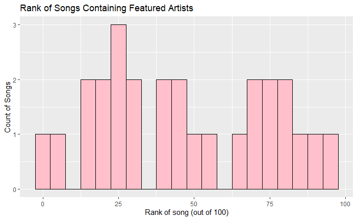

```r
featured %>%
  ggplot(aes(x = Rank)) +
  geom_histogram(binwidth = 5, color = "black", fill = "pink") +
  labs(title = "Rank of Songs Containing Featured Artists", x = "Rank of song (out of 100)", y = "Count of Songs")
```

As you can see on the graph above, the range of ranks that featured the most amount of artists were at 25, 45, and 75. This graph is showing that there probably was not an correlation between how well the song ranked, weather or not the song had someone featured on it.

## 2.1 Our Thoughts

We were kind of surprised with the data because there wasn’t a big jump in the rank compared to featured artists.We thought there was going to be more of a correlation between the two because we know from personal experience that were more apt to listen to a song if an artist we know is featured on it. As an example, the number 1 ranked song is “Uptown Funk” which is by Mark Ronson featuring Bruno Mars, but everyone knows the song because of Bruno Mars.

# 3 Question 2

### 3.0.1 How many songs say baby in the lyrics?

We wanted to answer this question because a common critique about modern music is how it repeatedly says the word baby, and we wanted to find out if that’s true.

The code below is creating another column of data that is figuring out whether or not that a song contains the lyric “baby”

```r
has_baby <- summer_hits %>%
  mutate(
      contains_baby = case_when(
      str_detect(Lyrics, "baby") ~ "yes",
      TRUE ~ "No"))
has_baby
```

| Rank | Song | Artist | Year | Lyrics | Source | contains_baby |
| --- | --- | --- | --- | --- | --- | --- |
| 1 | uptown funk | mark ronson featuring bruno mars | 2015 | this hit that ice cold michelle pfeiffer that white gold this one for them hood girls them good girls straight masterpieces stylin whilen livin it up in the city got chucks on with saint laurent got k… | 1 | No |
| 2 | thinking out loud | ed sheeran | 2015 | when your legs dont work like they used to before and i cant sweep you off of your feet will your mouth still remember the taste of my love will your eyes still smile from your cheeksand darling i wil… | 1 | yes |
| 3 | see you again | wiz khalifa featuring charlie puth | 2015 | its been a long day without you my friend and ill tell you all about it when i see you again weve come a long way from where we began oh ill tell you all about it when i see you again when i see you a… | 1 | No |
| 4 | trap queen | fetty wap | 2015 | im like hey wassup hello seen yo pretty ass soon as you came in the door i just wanna chill got a sack for us to roll married to the money introduced her to my stove showed her how to whip it now she … | 1 | yes |
| 5 | sugar | maroon 5 | 2015 | im hurting baby im broken down i need your loving loving i need it now when im without you im something weak you got me begging begging im on my kneesi dont wanna be needing your love i just wanna be … | 1 | yes |
| 6 | shut up and dance | walk the moon | 2015 | oh dont you dare look back just keep your eyes on me i said youre holding back she said shut up and dance with me this woman is my destiny she said oh oh oh shut up and dance with mewe were victims of… | 1 | No |
| 7 | blank space | taylor swift | 2015 | nice to meet you where you been i could show you incredible things magic madness heaven sin saw you there and i thought oh my god look at that face you look like my next mistake loves a game want to p… | 1 | yes |
| 8 | watch me | silento | 2015 | now watch me whip kill it now watch me nae nae okay now watch me whip whip watch me nae nae want me do itnow watch me whip kill it watch me nae nae okay now watch me whip whip watch me nae nae can you… | 1 | No |
| 9 | earned it | the weeknd | 2015 | you make it look like its magic cause i see nobody nobody but you you you im never confused hey heyim so used to being used so i love when you call unexpected cause i hate when the moments expected so… | 1 | No |
| 10 | the hills | the weeknd | 2015 | your man on the road he doin promo you said keep our business on the lowlow im just tryna get you out the friend zone cause you look even better than the photos i cant find your house send me the info… | 1 | No |

[output cut: 90 more lines]

Making the graphs:

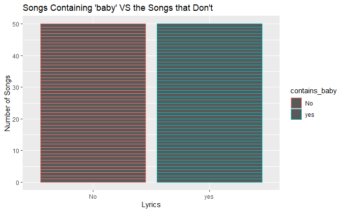

```r
ggplot(has_baby) +
  geom_col(aes(x = contains_baby, y = 1, color = contains_baby)) +
  labs(title = "Songs Containing 'baby' VS the Songs that Don't", x = "Lyrics", y = "Number of Songs")
```

The graph above is showing that there is the exact same number of songs that have the lyric baby.

Pulling the data:

```r
has_baby %>%
  filter(contains_baby == "yes")
```

| Rank | Song | Artist | Year | Lyrics | Source | contains_baby |
| --- | --- | --- | --- | --- | --- | --- |
| 2 | thinking out loud | ed sheeran | 2015 | when your legs dont work like they used to before and i cant sweep you off of your feet will your mouth still remember the taste of my love will your eyes still smile from your cheeksand darling i wil… | 1 | yes |
| 4 | trap queen | fetty wap | 2015 | im like hey wassup hello seen yo pretty ass soon as you came in the door i just wanna chill got a sack for us to roll married to the money introduced her to my stove showed her how to whip it now she … | 1 | yes |
| 5 | sugar | maroon 5 | 2015 | im hurting baby im broken down i need your loving loving i need it now when im without you im something weak you got me begging begging im on my kneesi dont wanna be needing your love i just wanna be … | 1 | yes |
| 7 | blank space | taylor swift | 2015 | nice to meet you where you been i could show you incredible things magic madness heaven sin saw you there and i thought oh my god look at that face you look like my next mistake loves a game want to p… | 1 | yes |
| 11 | cheerleader | omi | 2015 | when i need motivation my one solution is my queen cause she stay strong yeah yeah she is always in my corner right there when i want her all these other girls are tempting but im empty when youre gon… | 1 | yes |
| 12 | cant feel my face | the weeknd | 2015 | and i know shell be the death of me at least well both be numb and shell always get the best of me the worst is yet to come but at least well both be beautiful and stay forever young this i know yeah … | 1 | yes |
| 15 | bad blood | taylor swift featuring kendrick lamar | 2015 | cause baby now we got bad blood you know it used to be mad love so take a look at what youve done cause baby now we got bad bloodhey now we got problems and i dont think we can solve them you made a r… | 1 | yes |
| 17 | want to want me | jason derulo | 2015 | its too hard to sleep i got the sheets on the floor nothing on me and i cant take it no more its a hundred degrees i got one foot out the door where are my keys cause i gotta leave yeah in the back of… | 1 | yes |
| 18 | shake it off | taylor swift | 2015 | i stay up too late got nothing in my brain thats what people say mmm thats what people say mm i go on too many dates but i cant make em stay at least thats what people say mmm thats what people say mm… | 1 | yes |
| 21 | 679 | fetty wap featuring remy boyz | 2015 | baby girl youre so damn fine though im tryna know if i could hit it from behind though im sipping on you like some fine wine though and when its over i press rewind though you talking bands girl i got… | 1 | yes |

[output cut: 40 more lines]

The dataset above is showing a decently even dispursement of songs that contain the word baby.

The code below is creating another column of data that is figuring out whether or not that a song contains the lyric “girl”

```r
has_girl <- summer_hits %>%
  mutate(
    contains_girl = case_when(
      str_detect(Lyrics, "girl") ~ "yes",
      TRUE ~ "No"
    )
  )
has_girl
```

| Rank | Song | Artist | Year | Lyrics | Source | contains_girl |
| --- | --- | --- | --- | --- | --- | --- |
| 1 | uptown funk | mark ronson featuring bruno mars | 2015 | this hit that ice cold michelle pfeiffer that white gold this one for them hood girls them good girls straight masterpieces stylin whilen livin it up in the city got chucks on with saint laurent got k… | 1 | yes |
| 2 | thinking out loud | ed sheeran | 2015 | when your legs dont work like they used to before and i cant sweep you off of your feet will your mouth still remember the taste of my love will your eyes still smile from your cheeksand darling i wil… | 1 | No |
| 3 | see you again | wiz khalifa featuring charlie puth | 2015 | its been a long day without you my friend and ill tell you all about it when i see you again weve come a long way from where we began oh ill tell you all about it when i see you again when i see you a… | 1 | No |
| 4 | trap queen | fetty wap | 2015 | im like hey wassup hello seen yo pretty ass soon as you came in the door i just wanna chill got a sack for us to roll married to the money introduced her to my stove showed her how to whip it now she … | 1 | No |
| 5 | sugar | maroon 5 | 2015 | im hurting baby im broken down i need your loving loving i need it now when im without you im something weak you got me begging begging im on my kneesi dont wanna be needing your love i just wanna be … | 1 | yes |
| 6 | shut up and dance | walk the moon | 2015 | oh dont you dare look back just keep your eyes on me i said youre holding back she said shut up and dance with me this woman is my destiny she said oh oh oh shut up and dance with mewe were victims of… | 1 | No |
| 7 | blank space | taylor swift | 2015 | nice to meet you where you been i could show you incredible things magic madness heaven sin saw you there and i thought oh my god look at that face you look like my next mistake loves a game want to p… | 1 | yes |
| 8 | watch me | silento | 2015 | now watch me whip kill it now watch me nae nae okay now watch me whip whip watch me nae nae want me do itnow watch me whip kill it watch me nae nae okay now watch me whip whip watch me nae nae can you… | 1 | No |
| 9 | earned it | the weeknd | 2015 | you make it look like its magic cause i see nobody nobody but you you you im never confused hey heyim so used to being used so i love when you call unexpected cause i hate when the moments expected so… | 1 | yes |
| 10 | the hills | the weeknd | 2015 | your man on the road he doin promo you said keep our business on the lowlow im just tryna get you out the friend zone cause you look even better than the photos i cant find your house send me the info… | 1 | yes |

[output cut: 90 more lines]

Making the graph:

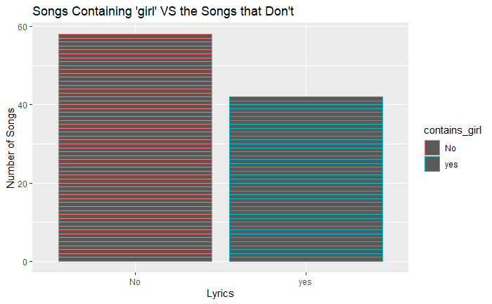

```r
ggplot(has_girl) +
  geom_col(aes(x = contains_girl, y = 1, color = contains_girl)) +
  labs(title = "Songs Containing 'girl' VS the Songs that Don't", x = "Lyrics", y = "Number of Songs")
```

The graph above shows that there are 42 songs containg the lyric “girl”

Pulling the data:

```r
has_girl %>%
  filter(contains_girl == "yes")
```

| Rank | Song | Artist | Year | Lyrics | Source | contains_girl |
| --- | --- | --- | --- | --- | --- | --- |
| 1 | uptown funk | mark ronson featuring bruno mars | 2015 | this hit that ice cold michelle pfeiffer that white gold this one for them hood girls them good girls straight masterpieces stylin whilen livin it up in the city got chucks on with saint laurent got k… | 1 | yes |
| 5 | sugar | maroon 5 | 2015 | im hurting baby im broken down i need your loving loving i need it now when im without you im something weak you got me begging begging im on my kneesi dont wanna be needing your love i just wanna be … | 1 | yes |
| 7 | blank space | taylor swift | 2015 | nice to meet you where you been i could show you incredible things magic madness heaven sin saw you there and i thought oh my god look at that face you look like my next mistake loves a game want to p… | 1 | yes |
| 9 | earned it | the weeknd | 2015 | you make it look like its magic cause i see nobody nobody but you you you im never confused hey heyim so used to being used so i love when you call unexpected cause i hate when the moments expected so… | 1 | yes |
| 10 | the hills | the weeknd | 2015 | your man on the road he doin promo you said keep our business on the lowlow im just tryna get you out the friend zone cause you look even better than the photos i cant find your house send me the info… | 1 | yes |
| 11 | cheerleader | omi | 2015 | when i need motivation my one solution is my queen cause she stay strong yeah yeah she is always in my corner right there when i want her all these other girls are tempting but im empty when youre gon… | 1 | yes |
| 12 | cant feel my face | the weeknd | 2015 | and i know shell be the death of me at least well both be numb and shell always get the best of me the worst is yet to come but at least well both be beautiful and stay forever young this i know yeah … | 1 | yes |
| 14 | take me to church | hozier | 2015 | my lovers got humour shes the giggle at a funeral knows everybodys disapproval i shouldve worshipped her sooner if the heavens ever did speak she is the last true mouthpiece every sundays getting more… | 1 | yes |
| 17 | want to want me | jason derulo | 2015 | its too hard to sleep i got the sheets on the floor nothing on me and i cant take it no more its a hundred degrees i got one foot out the door where are my keys cause i gotta leave yeah in the back of… | 1 | yes |
| 18 | shake it off | taylor swift | 2015 | i stay up too late got nothing in my brain thats what people say mmm thats what people say mm i go on too many dates but i cant make em stay at least thats what people say mmm thats what people say mm… | 1 | yes |

[output cut: 32 more lines]

The code below is creating another column of data that is figuring out whether or not that a song contains the lyric “boy”

```r
has_boy <- summer_hits %>%
  mutate(
    contains_boy = case_when(
      str_detect(Lyrics, "Boy") ~ "yes",
      TRUE ~ "No"
    )
  )
has_boy
```

| Rank | Song | Artist | Year | Lyrics | Source | contains_boy |
| --- | --- | --- | --- | --- | --- | --- |
| 1 | uptown funk | mark ronson featuring bruno mars | 2015 | this hit that ice cold michelle pfeiffer that white gold this one for them hood girls them good girls straight masterpieces stylin whilen livin it up in the city got chucks on with saint laurent got k… | 1 | No |
| 2 | thinking out loud | ed sheeran | 2015 | when your legs dont work like they used to before and i cant sweep you off of your feet will your mouth still remember the taste of my love will your eyes still smile from your cheeksand darling i wil… | 1 | No |
| 3 | see you again | wiz khalifa featuring charlie puth | 2015 | its been a long day without you my friend and ill tell you all about it when i see you again weve come a long way from where we began oh ill tell you all about it when i see you again when i see you a… | 1 | No |
| 4 | trap queen | fetty wap | 2015 | im like hey wassup hello seen yo pretty ass soon as you came in the door i just wanna chill got a sack for us to roll married to the money introduced her to my stove showed her how to whip it now she … | 1 | No |
| 5 | sugar | maroon 5 | 2015 | im hurting baby im broken down i need your loving loving i need it now when im without you im something weak you got me begging begging im on my kneesi dont wanna be needing your love i just wanna be … | 1 | No |
| 6 | shut up and dance | walk the moon | 2015 | oh dont you dare look back just keep your eyes on me i said youre holding back she said shut up and dance with me this woman is my destiny she said oh oh oh shut up and dance with mewe were victims of… | 1 | No |
| 7 | blank space | taylor swift | 2015 | nice to meet you where you been i could show you incredible things magic madness heaven sin saw you there and i thought oh my god look at that face you look like my next mistake loves a game want to p… | 1 | No |
| 8 | watch me | silento | 2015 | now watch me whip kill it now watch me nae nae okay now watch me whip whip watch me nae nae want me do itnow watch me whip kill it watch me nae nae okay now watch me whip whip watch me nae nae can you… | 1 | No |
| 9 | earned it | the weeknd | 2015 | you make it look like its magic cause i see nobody nobody but you you you im never confused hey heyim so used to being used so i love when you call unexpected cause i hate when the moments expected so… | 1 | No |
| 10 | the hills | the weeknd | 2015 | your man on the road he doin promo you said keep our business on the lowlow im just tryna get you out the friend zone cause you look even better than the photos i cant find your house send me the info… | 1 | No |

[output cut: 90 more lines]

Creating the graph:

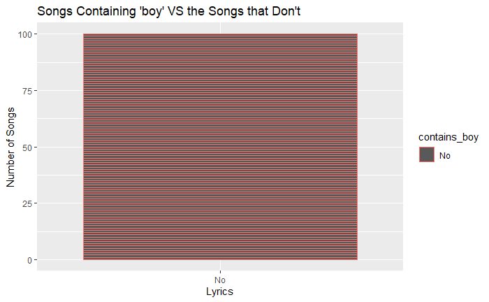

```r
ggplot(has_boy) +
  geom_col(aes(x = contains_boy, y = 1, color = contains_boy)) +
  labs(title = "Songs Containing 'boy' VS the Songs that Don't", x = "Lyrics", y = "Number of Songs")
```

# 4 Conclusion